# Average Income vs Average Housing by State

## Part Two: Data Management

### Tidy Data

Then, we tidied the data by removing unnecessary information, handling improper types, as well as organizing by the most relevant information.

The housing dataset contained information about every state in the US. We first filtered to include entries in Maryland. Then, we noticed that the “year” and “HPI with 2000 base” columns had non-numeric entries, so we casted them to numeric values for easier manipulation in graph visualizations. Finally, we filtered out the data to only include information from the year 2000 and ahead, as the latest available base HPI of 100 was in 2000, and the income data we would compare against begins in 2010. Later in our code we adjust the housing frame to align with the income years.

```python
housing_df = main_df.copy(deep=True)
## Tidying data for housing dataframe
housing_df.columns = ['State', 'County', 'FIPS code', 'Year', 'Annual Change(%)', 'HPI', 'HPI with 1990 base', 'HPI with 2000 base']
# Extracting rows with MD data
housing_df = housing_df.iloc[35092:36048]
# Changing type of Year column to numeric value
housing_df["Year"] = pd.to_numeric(housing_df["Year"])
housing_df["HPI with 2000 base"] = pd.to_numeric(housing_df["HPI with 2000 base"], errors='coerce')
# Since we are only looking at data after the year 2000, we must filter the data for those years
housing_df = housing_df[housing_df['Year'] >= 2000]
# Resetting the index for the updated dataframe
housing_df.reset_index(inplace=True)
housing_df.drop(columns=['index'], inplace=True)
housing_df
```

|  | State | County | FIPS code | Year | Annual Change(%) | HPI | HPI with 1990 base | HPI with 2000 base |
| --- | --- | --- | --- | --- | --- | --- | --- | --- |
| 0 | MD | Allegany | 24001 | 2000 | 1.06 | 172.52 | 139.46 | 100.00 |
| 1 | MD | Allegany | 24001 | 2001 | 4.71 | 180.65 | 146.03 | 104.71 |
| 2 | MD | Allegany | 24001 | 2002 | 2.89 | 185.86 | 150.24 | 107.74 |
| 3 | MD | Allegany | 24001 | 2003 | 2.29 | 190.12 | 153.69 | 110.21 |
| 4 | MD | Allegany | 24001 | 2004 | 6.21 | 201.94 | 163.23 | 117.05 |
| ... | ... | ... | ... | ... | ... | ... | ... | ... |
| 499 | MD | Baltimore City | 24510 | 2016 | 2.86 | 689.27 | 228.52 | 177.64 |
| 500 | MD | Baltimore City | 24510 | 2017 | 2.51 | 706.58 | 234.27 | 182.11 |
| 501 | MD | Baltimore City | 24510 | 2018 | 1.50 | 717.15 | 237.77 | 184.83 |
| 502 | MD | Baltimore City | 24510 | 2019 | 1.39 | 727.16 | 241.09 | 187.41 |
| 503 | MD | Baltimore City | 24510 | 2020 | 2.59 | 746.02 | 247.34 | 192.27 |

504 rows × 8 columns

```python
## Tidying data for income dataframe
income_df.drop(columns=['Date created'], inplace=True)
income_df = income_df[income_df['Data'] == "Income"]
income_df
```

|  | Year | Data | MARYLAND | Allegany County | Anne Arundel County | Baltimore City | Baltimore County | Calvert County | Caroline County | Carroll County | ... | Kent County | Montgomery County | Prince George's County | Queen Anne's County | Somerset County | St. Mary's County | Talbot County | Washington County | Wicomico County | Worcester County |
| --- | --- | --- | --- | --- | --- | --- | --- | --- | --- | --- | --- | --- | --- | --- | --- | --- | --- | --- | --- | --- | --- |
| 0 | 2010 | Income | 68933 | 37083 | 80908 | 38186 | 62300 | 86536 | 55480 | 80291 | ... | 49017 | 88559 | 69524 | 78503 | 38134 | 81559 | 56806 | 51610 | 47702 | 55492 |
| 2 | 2011 | Income | 70075 | 38504 | 82980 | 38478 | 62309 | 88406 | 50809 | 82553 | ... | 49795 | 92288 | 70114 | 75158 | 35426 | 80943 | 55145 | 52028 | 45788 | 48472 |
| 4 | 2012 | Income | 71169 | 38670 | 87083 | 39077 | 62413 | 87215 | 48772 | 79304 | ... | 49969 | 94365 | 69258 | 79012 | 34454 | 85478 | 61529 | 52604 | 50204 | 55875 |
| 6 | 2013 | Income | 72482 | 39994 | 85685 | 41988 | 64624 | 91993 | 46015 | 82073 | ... | 55695 | 97873 | 71682 | 80143 | 36106 | 78274 | 57525 | 55643 | 47536 | 52276 |
| 8 | 2014 | Income | 73851 | 39808 | 86654 | 41895 | 67766 | 92446 | 49573 | 84500 | ... | 53288 | 97279 | 71904 | 80650 | 38376 | 84686 | 54836 | 54606 | 51927 | 55691 |
| 10 | 2015 | Income | 75784 | 39859 | 90825 | 43192 | 68317 | 98937 | 51294 | 84506 | ... | 52274 | 98314 | 76366 | 83914 | 38692 | 83148 | 62018 | 55270 | 52153 | 53366 |
| 12 | 2016 | Income | 78787 | 44708 | 95297 | 46604 | 72305 | 97188 | 49616 | 89529 | ... | 54210 | 99604 | 78680 | 79966 | 38546 | 80049 | 62264 | 54643 | 50015 | 53509 |
| 14 | 2017 | Income | 80711 | 42564 | 96133 | 46762 | 73309 | 100000 | 56338 | 92890 | ... | 57760 | 102944 | 80858 | 90696 | 40320 | 82433 | 70620 | 59828 | 52341 | 61405 |
| 16 | 2018 | Income | 83076 | 43535 | 97051 | 50501 | 75836 | 106270 | 56627 | 95956 | ... | 55514 | 107758 | 82445 | 93751 | 42098 | 89964 | 64245 | 62556 | 54313 | 59266 |

9 rows × 27 columns

### Missing Data

Now that we’ve tidied the data, we must check for other obstacles in the dataframes. The data set can contain missing values (NaN's) which can cause problems later on during our analysis. We learned that there are three viable methods to deal with missing data: remove missing data, encode the missing data, or impute the missing data.

First, we will check for missing data in our datasets. For both datasets, we tracked the number of missing values. We found that there are no missing values in our dataset. Just to be safe, we called the method to drop any nan values, but it should not have any impact.

```python
housing_df.dropna()
income_df.dropna()
```

|  | Year | Data | MARYLAND | Allegany County | Anne Arundel County | Baltimore City | Baltimore County | Calvert County | Caroline County | Carroll County | ... | Kent County | Montgomery County | Prince George's County | Queen Anne's County | Somerset County | St. Mary's County | Talbot County | Washington County | Wicomico County | Worcester County |
| --- | --- | --- | --- | --- | --- | --- | --- | --- | --- | --- | --- | --- | --- | --- | --- | --- | --- | --- | --- | --- | --- |
| 0 | 2010 | Income | 68933 | 37083 | 80908 | 38186 | 62300 | 86536 | 55480 | 80291 | ... | 49017 | 88559 | 69524 | 78503 | 38134 | 81559 | 56806 | 51610 | 47702 | 55492 |
| 2 | 2011 | Income | 70075 | 38504 | 82980 | 38478 | 62309 | 88406 | 50809 | 82553 | ... | 49795 | 92288 | 70114 | 75158 | 35426 | 80943 | 55145 | 52028 | 45788 | 48472 |
| 4 | 2012 | Income | 71169 | 38670 | 87083 | 39077 | 62413 | 87215 | 48772 | 79304 | ... | 49969 | 94365 | 69258 | 79012 | 34454 | 85478 | 61529 | 52604 | 50204 | 55875 |
| 6 | 2013 | Income | 72482 | 39994 | 85685 | 41988 | 64624 | 91993 | 46015 | 82073 | ... | 55695 | 97873 | 71682 | 80143 | 36106 | 78274 | 57525 | 55643 | 47536 | 52276 |
| 8 | 2014 | Income | 73851 | 39808 | 86654 | 41895 | 67766 | 92446 | 49573 | 84500 | ... | 53288 | 97279 | 71904 | 80650 | 38376 | 84686 | 54836 | 54606 | 51927 | 55691 |
| 10 | 2015 | Income | 75784 | 39859 | 90825 | 43192 | 68317 | 98937 | 51294 | 84506 | ... | 52274 | 98314 | 76366 | 83914 | 38692 | 83148 | 62018 | 55270 | 52153 | 53366 |
| 12 | 2016 | Income | 78787 | 44708 | 95297 | 46604 | 72305 | 97188 | 49616 | 89529 | ... | 54210 | 99604 | 78680 | 79966 | 38546 | 80049 | 62264 | 54643 | 50015 | 53509 |
| 14 | 2017 | Income | 80711 | 42564 | 96133 | 46762 | 73309 | 100000 | 56338 | 92890 | ... | 57760 | 102944 | 80858 | 90696 | 40320 | 82433 | 70620 | 59828 | 52341 | 61405 |
| 16 | 2018 | Income | 83076 | 43535 | 97051 | 50501 | 75836 | 106270 | 56627 | 95956 | ... | 55514 | 107758 | 82445 | 93751 | 42098 | 89964 | 64245 | 62556 | 54313 | 59266 |

9 rows × 27 columns

## Part Three: Exploratory Data Analysis

Exploratory data analysis (EDA) is used to analyze and investigate data sets and summarize their main characteristics, usually by employing data visualization methods. EDA is critical to finding patterns in datasets that can be used for further investigation. Below, we will explore the two datasets in our project.

First, we will explore the HPI data. We created line graphs to visualize the HPI change overtime in each county. Just by first glance at the graphs, we can see that there are shared characteristics across all of the counties. Across counties, the HPI typically reaches a peak between the years 2005 and 2007, and dips in the year 2012. The 2012 dip aligns with the general state of the US economy; drowning in debt. According to The Balance, at the end of 2012, the U.S. debt was 16.05 trillion dollars. That made the debt-to-GDP ratio 100 percent, higher than at any time since World War II. Debt was driven by government spending and reduced revenue from taxes, thanks to slow economic growth. The Fiscal Year 2012 budget deficit was $1.077 trillion.

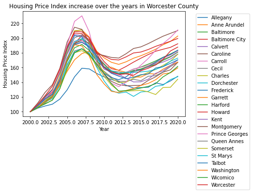

```python
fig, ax = plt.subplots()

county_groups = housing_df.groupby('County')
for key,group in county_groups:
    plt.plot(group['Year'], group['HPI with 2000 base'], label=key)
    plt.xlabel("Year")
    plt.ylabel("Housing Price Index")
    plt.title("Housing Price Index increase over the years in " + key + " County")
plt.legend(bbox_to_anchor=(1.05, 1), loc='upper left')
```

Then, we explored the income data, by county. The first observation that comes to mind is that there is not a noticeable characteristic, such as the dip in housing, that resonates in income across all counties. There are however many more localized peaks in trends for each county. This informs us that there are high fluctuations in median personal income, which can be caused by external factors - such as job opportunities, wage policies, etc. While there isn’t a perfect trend that registers in income across all counties, it is important to notice that most counties have had a positive growth in income over time.

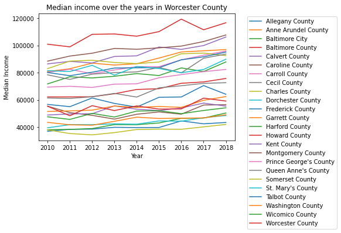

```python
fig, ax = plt.subplots()

for colName, col in income_df.iteritems():
    if colName != "Year" and colName != "Data" and colName != "MARYLAND":
        plt.plot(income_df['Year'], col, label=colName)
        plt.xlabel("Year")
        plt.ylabel("Median Income")
        plt.title("Median income over the years in " + colName)
plt.legend(bbox_to_anchor=(1.05, 1), loc='upper left')
```

In the following code, we calculate the percentage change in HPI for each county by year. We use a 2-dimensional array to store these calculations. The first layer of the array contains the different counties, and the inner array for each county contain the percent change over each year. For each year, we calculate the percent change to the next year, and append it to the inner array. Our code accounts for when counties change in the dataset as well as the size of the dataset.

```python
# To get the percentage change for every county by year. The overarching array represents the different counties, and the inner arrays are the percentage changes
# every year for that particular county
percent_change_df = housing_df[housing_df['Year'] >= 2010]
percent_change_df = percent_change_df[percent_change_df['Year'] <= 2018]
hpi_changes = []
county_change = []
percent_change_df.reset_index(inplace=True)

for index, row in percent_change_df.iterrows():
    if index < percent_change_df.shape[0] - 1:
        original = percent_change_df.iloc[index]['HPI with 2000 base']
        next_year_val = percent_change_df.iloc[index + 1]['HPI with 2000 base']
        percent_change = ((next_year_val - original)/original) * 100
        current_county = percent_change_df.iloc[index]['County']
        next_county = percent_change_df.iloc[index + 1]['County']
        if current_county == next_county:
            county_change.append(percent_change)
        else:
            hpi_changes.append(county_change)
            county_change = []
```

Next, we perform similar calculations for the income dataset, calculating change in median income for each county by year. We also use the 2-dimensional array approach in these calculations.

```python
# Same as above, but this is for income
income_changes = []
county_change = []
for colName, col in income_df.iteritems():
    if colName != "Year" and colName != "Data" and colName != "MARYLAND":
        idx = 0
        for income in col:
            if idx < income_df.shape[0] - 1:
                next_year_income = income_df.iloc[idx + 1][colName]
                percent_change = ((next_year_income - income)/income) * 100
                county_change.append(percent_change)
                idx += 1
        income_changes.append(county_change)
        county_change = []
```

Finally, we plot the data we calculated into a double bar graph for each county. For each county, we plot the percent change in HPI vs percent change in median personal income by year. By plotting these against each other, we can demonstrate if the home appreciation parallels median income. Each county is vastly different from one another. For example, in Baltimore County, beginning in the year 2013, the HPI index and median personal income are both increasing, but the median personal income grew much more rapidly than the HPI index. Conversely, in Harford County, in 2017, the median income largely decreased while the HIP index increased 2 percent, meaning that the houses were more expensive than affordable for people earning around the median income. This kind of data assists in demonstrating the patterns of financial affordability in terms of cost of living in different counties of Maryland. After synthesizing the data that we explored, the next step is to test a hypothesis.

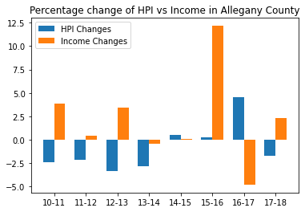

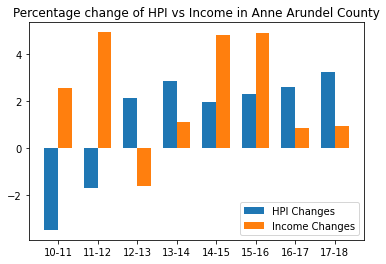

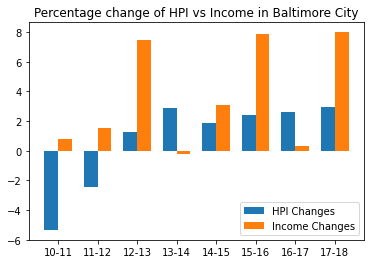

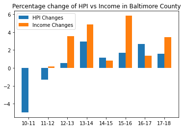

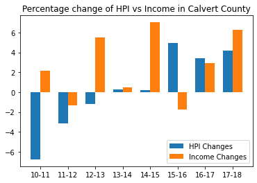

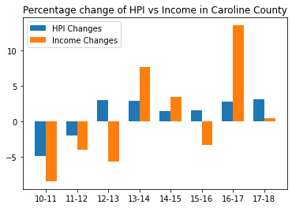

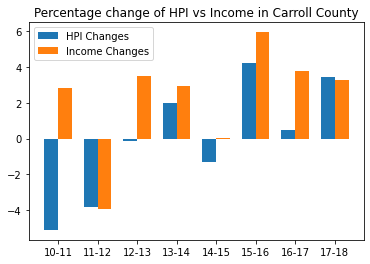

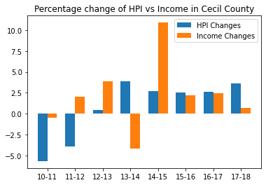

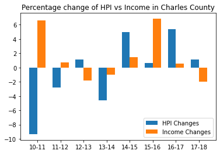

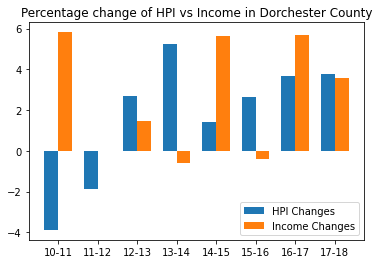

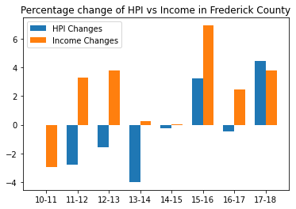

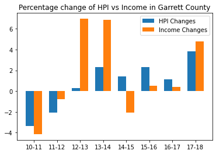

[11 more figures not shown]

```python
count = 0
counties = np.array(income_df.columns[3:])
for row in hpi_changes:
    ax = plt.subplot(111)
    years = ['10-11', '11-12', '12-13', '13-14', '14-15', '15-16', '16-17', '17-18']

    ind = np.arange(8)
    width = 0.35
    ax.bar(ind, row, width, label='HPI Changes')
    ax.bar(ind + width, income_changes[count], width, label='Income Changes')

    ax.set_xticks(ind + width / 2)
    ax.set_xticklabels(('10-11', '11-12', '12-13', '13-14', '14-15', '15-16', '16-17', '17-18'))
    ax.legend()
    ax.set_title("Percentage change of HPI vs Income in " + counties[count])
    plt.show()
    count += 1
```

## Part Four: Hypothesis Testing

Hypothesis testing is a statistical method of determining if your created model is a good fit or not. As the name indicates, in hypothesis testing you will have two hypotheses: a null hypothesis and an alternative hypothesis. You want to set up your hypothesis such that you reject the null hypothesis. What does it mean to reject the hypothesis though? This is where significance level comes into the picture. When setting up your experiment, in addition to the hypotheses, you set a significance level. If the p value of your random varaiable in within your siginficance level, also known as the rejection level, you reject the null hypothesis. While determining whether to reject your null hypothesis or not, be careful to determine what type of test you are setting up; is it one-tailed or two-tailed?

The code below creates scatter plots for each year from the years 2010-2018, and uses the counties HPI index and the Median Income for that county to try and see if there is a relationship between the HPI index and the median income. After the scatter plot is created, a linear regression line is fit on the data to see if there is a linear relationship between the two values.

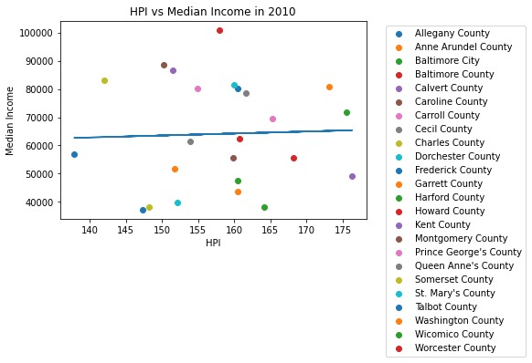

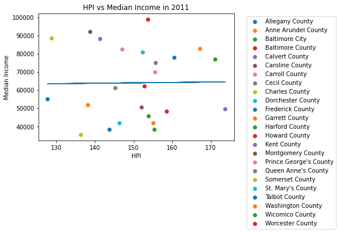

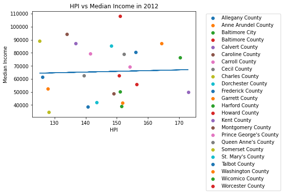

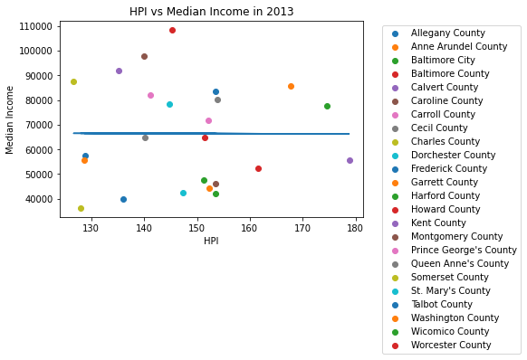

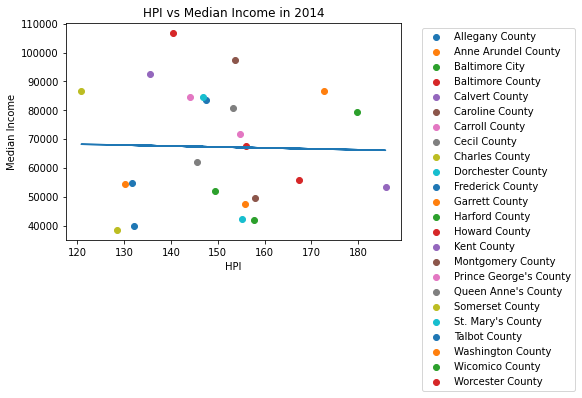

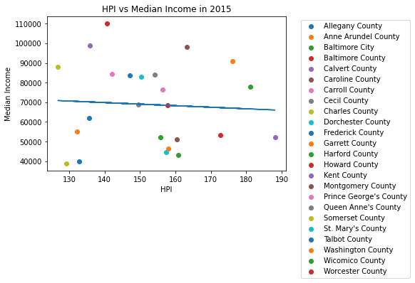

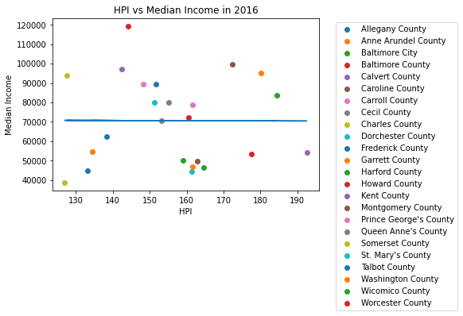

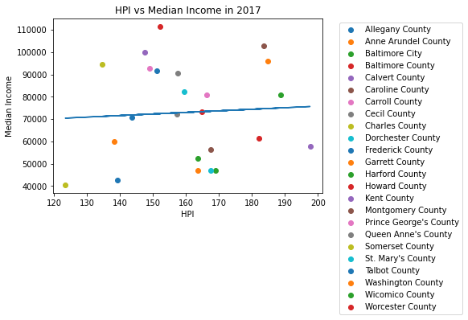

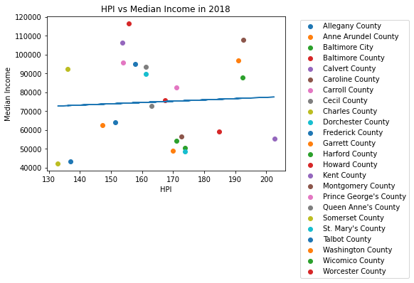

```python
hpi_counties = housing_df['County'].unique()
for year in [2010, 2011, 2012, 2013, 2014, 2015, 2016, 2017, 2018]:
    idx = 0
    for county in counties:
        income_row = income_df.loc[income_df['Year'] == year]
        income = income_row[county]
        hpi_row = housing_df.loc[housing_df['Year'] == year]
        hpi_temp = hpi_row[hpi_row['County'] == hpi_counties[idx]]
        hpi = hpi_temp["HPI with 2000 base"]
        idx += 1
        plt.scatter(x=hpi, y=income, label=county)

    hpi_rows = percent_change_df[percent_change_df['Year'] == year]
    hpi = np.array(hpi_rows['HPI with 2000 base']).reshape(-1, 1)
    income_row = income_df[income_df['Year'] == year]
    income = np.array(income_row.values[0][3:]).reshape(-1, 1)

    reg = LinearRegression().fit(hpi, income)
    plt.plot(hpi, reg.intercept_ + reg.coef_ * hpi, '-')
    plt.xlabel("HPI")
    plt.ylabel("Median Income")
    plt.title("HPI vs Median Income in " + str(year))
    plt.legend(bbox_to_anchor=(1.05, 1), loc='upper left')
    plt.show()
```

## Part Five: Communication of Insights

It is clear that our research is not sufficient to solve the issues surrounding income in the economy, but we are able to communicate a meaningful discussion about the affordability of the housing market in Maryland based on our results. The purpose of this tutorial is to demonstrate the application of the Data Science pipeline, and we hope you learned something new!